# MacrosystemGraphs_v1

sbsambado

9/28/2020

## **Macrosystem Proposal**

Data are from NEON

This is some EDA for a grant proposal with MacDonald et al.

Data analyzed are: **questing I. scapularis abundances across**

- sites of interest
- peak activity during months of March - September
- Years (2014 - 2019)attached

**attached I. scapularis on mammals across**

- sites of interest *attached tick data needs to be tidied up more since it’s currently in present/absent version*

Original csv’s are pulled from NEON. On my computer, these files are stored in a different R Project/Git Repository called ‘Macrosystems’

Andy’s code to tidy up csv’s

```
##          plotID     collectDate  scientificName        sexOrAge individualCount
##          "list"        "factor"        "factor"        "factor"       "integer"
##            site
##     "character"
```

```
##          plotID     collectDate  scientificName        sexOrAge individualCount
##          "list"        "factor"        "factor"        "factor"       "integer"
##            site
##     "character"
```

```
##          plotID     collectDate  scientificName        sexOrAge individualCount
##          "list"        "factor"        "factor"        "factor"       "integer"
##            site
##     "character"
```

Aggregated tick data

## Graph type 1

*Aggregated questing tick abundances by site by life stage per year*

- Don’t think these graphs are useful for the proposal but it was easier for me to visualize which sites are sampling more often
- Not a lot of data for larvae from 2016 and 2017 so those years were omitted, there is one sampling event > 3000 larvae were collected but omitted it to make a more cohesive graph

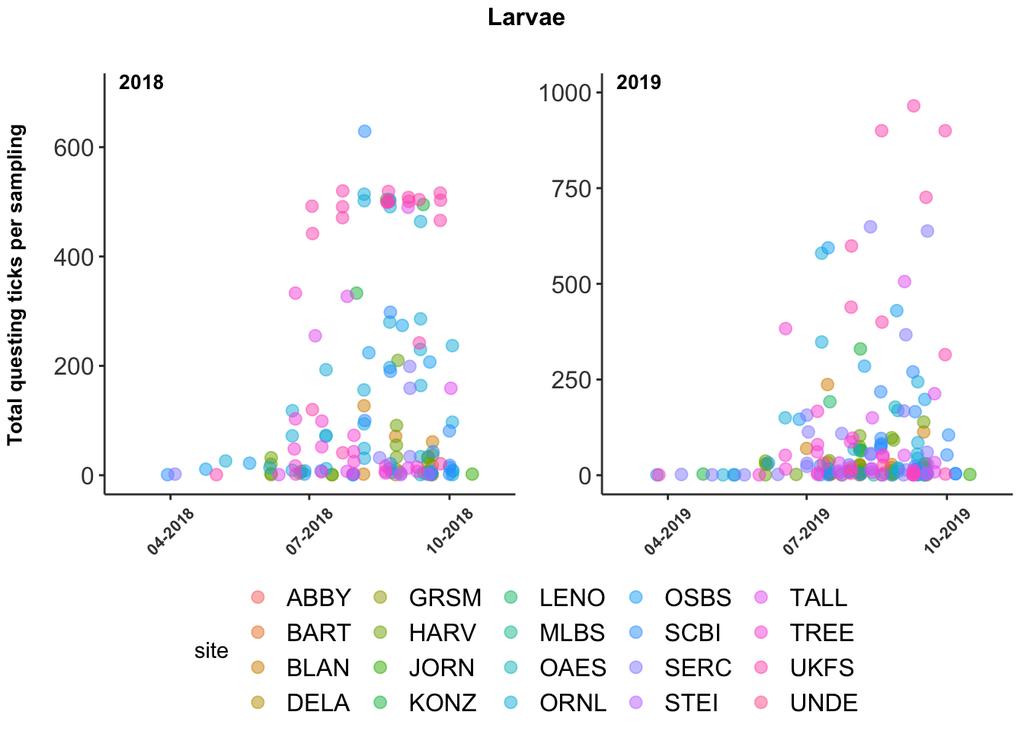

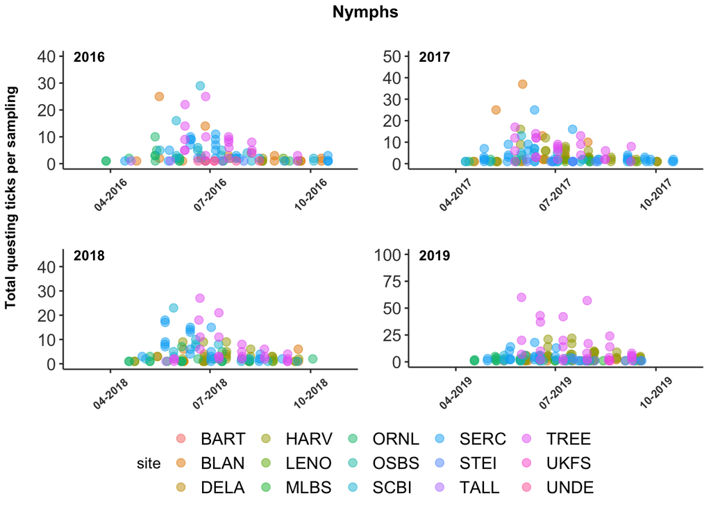

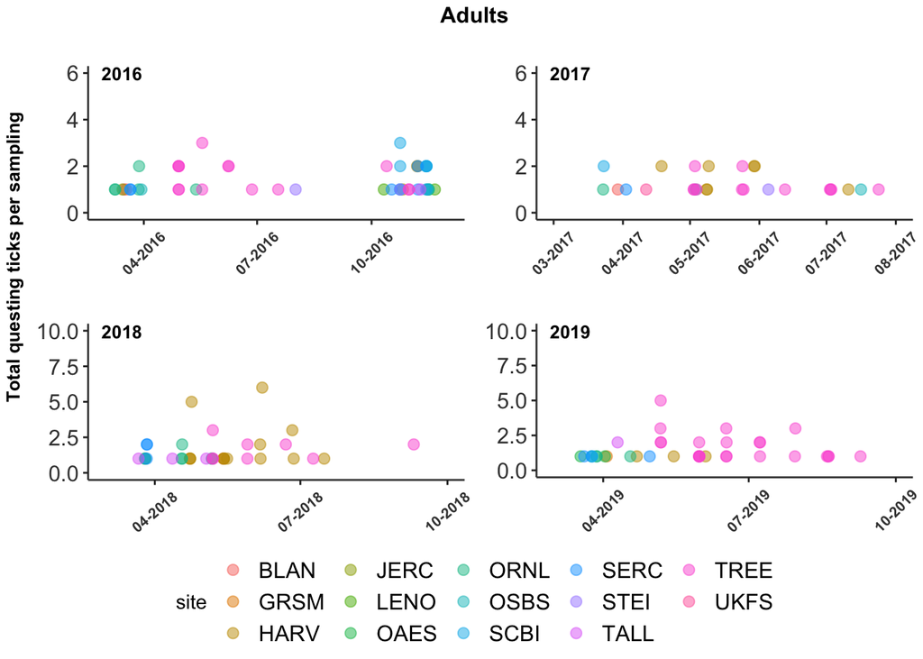

## Graph type 2

*Aggregated questing nymphal abundances by site by month per year

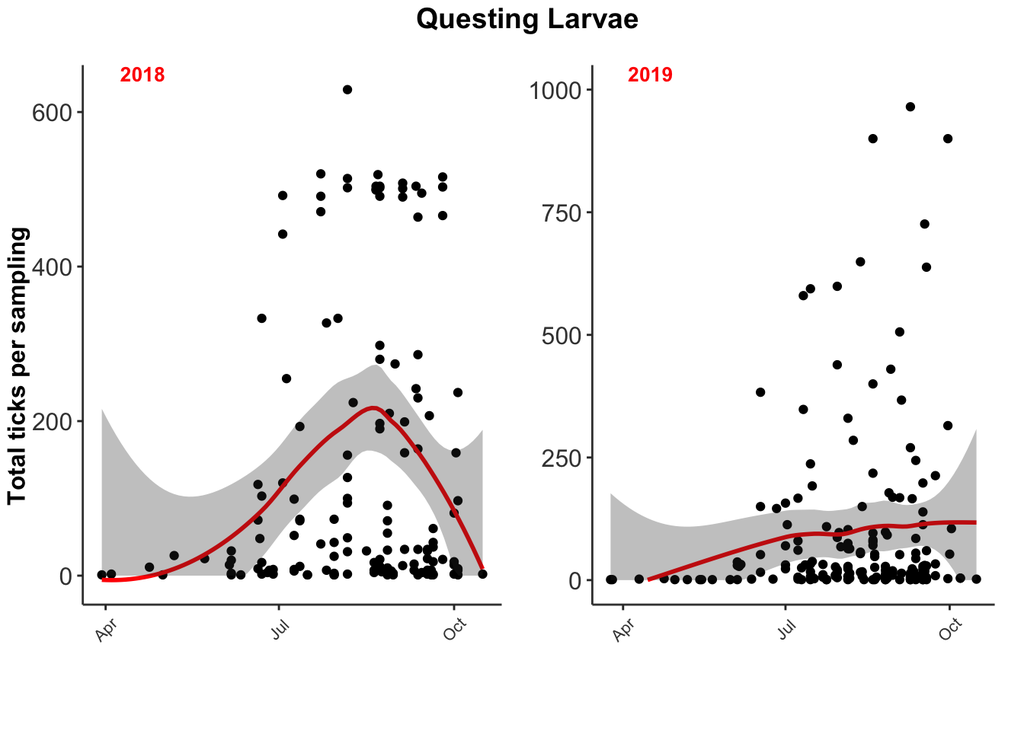

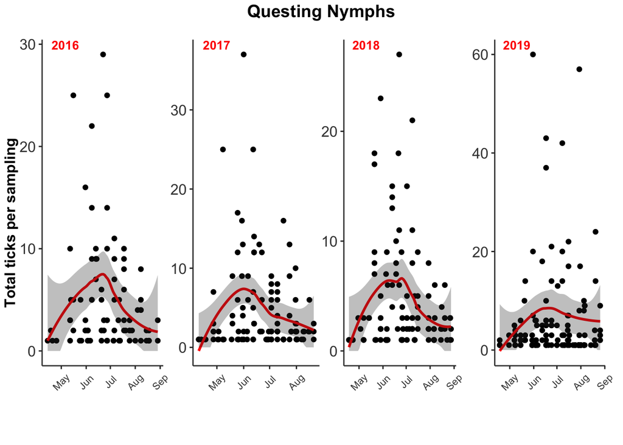

## Graph type 3

*Boxplots of total questing ticks by life stage and month per sampling (Years 2014 - 2019)*

- Just another way to visualize the phenology

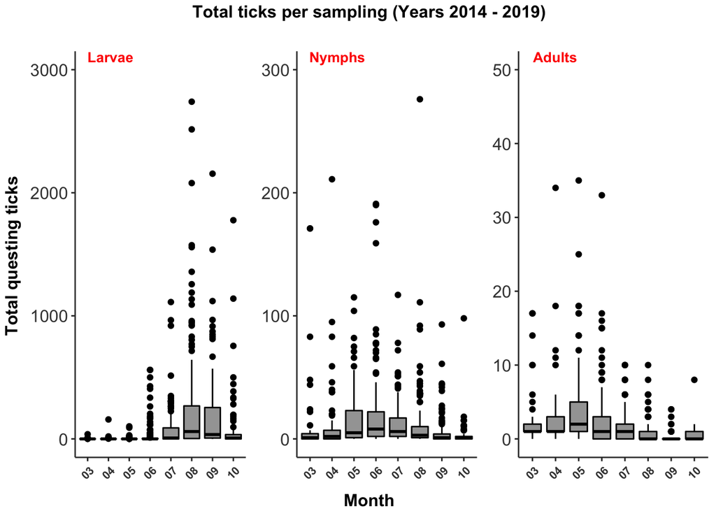

## **Graph type 4**

*Total questing ticks sampled per area (m) size with siteID*

- These graphs were less interesting to me but I can fiddle around with them more

**Type 4.A with no site identifier**

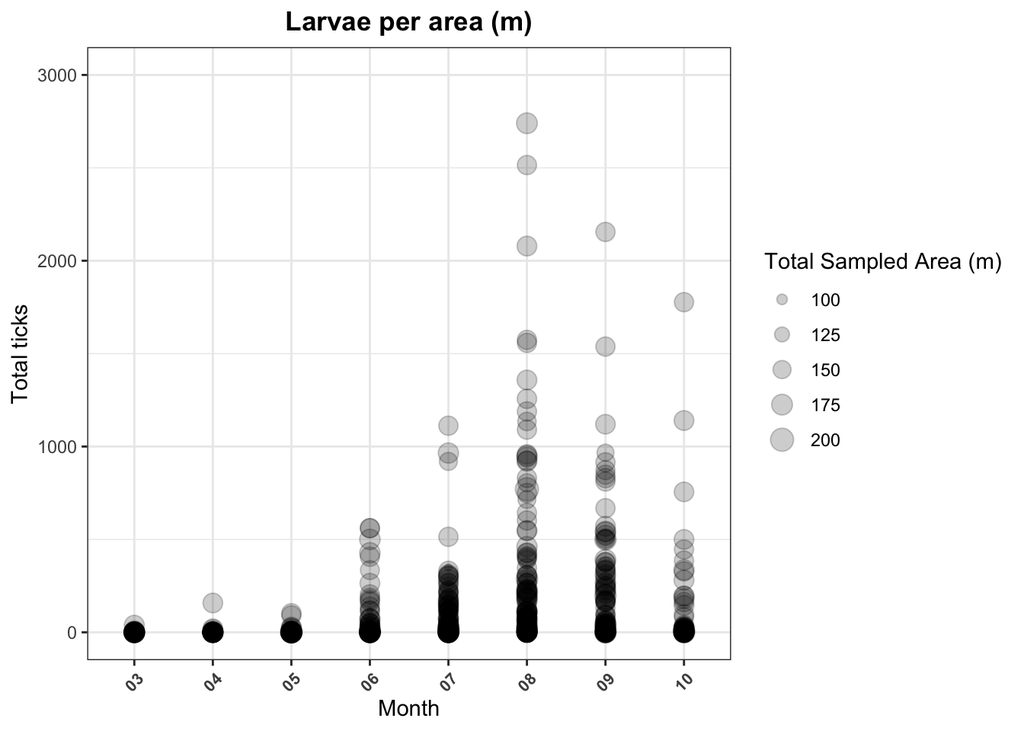

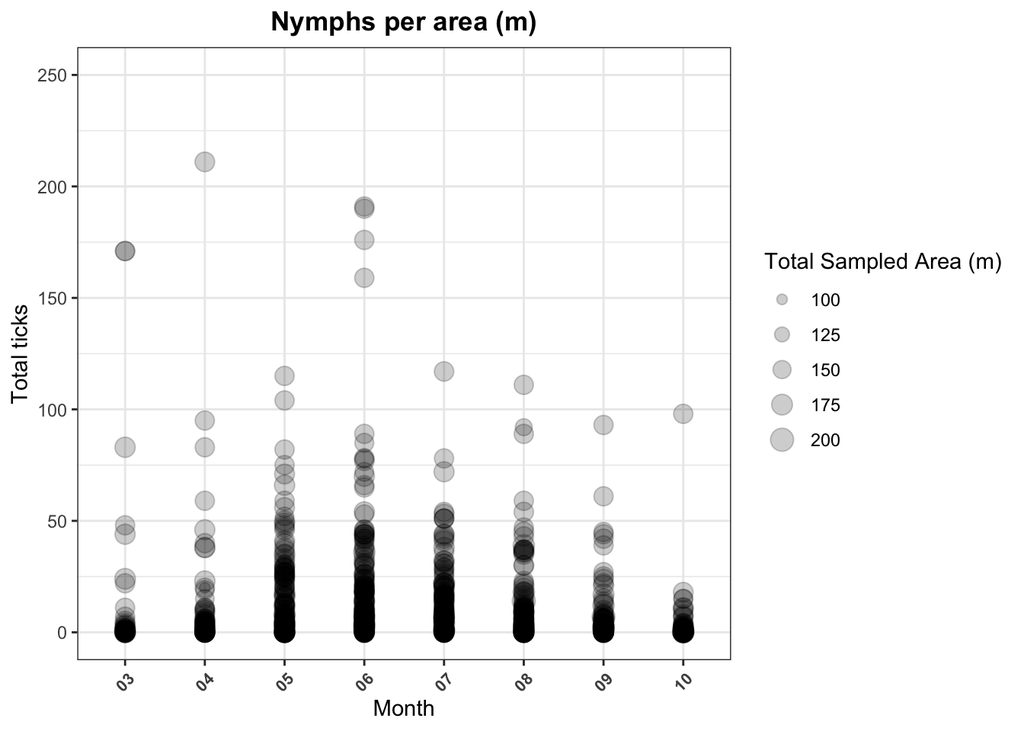

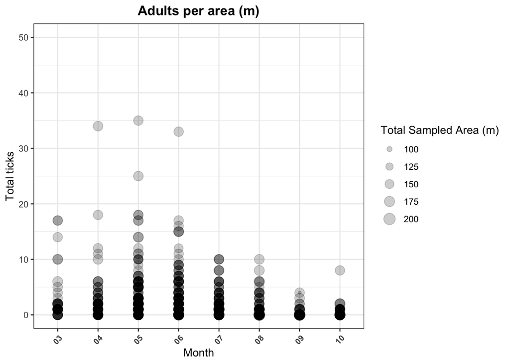

**Type 4.B with site identifier**

- Still not sure how helpful these graphs are

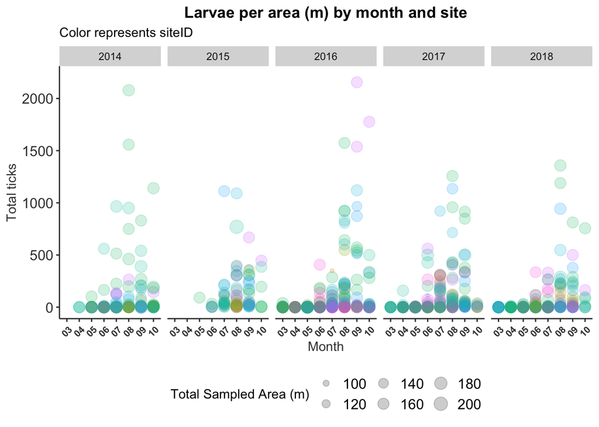

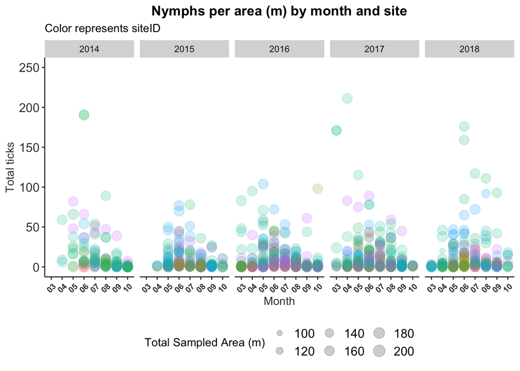

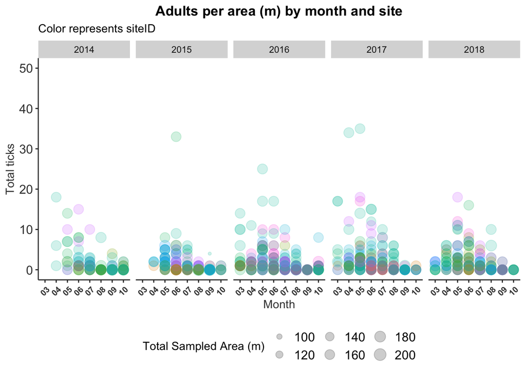

## **Graph type 5**

- Attached mammal ticks in Yes/No format
- This data is not as great, but let me know if there’s another way you would like me to represent it

**Type 5.A represents mammal sample size**

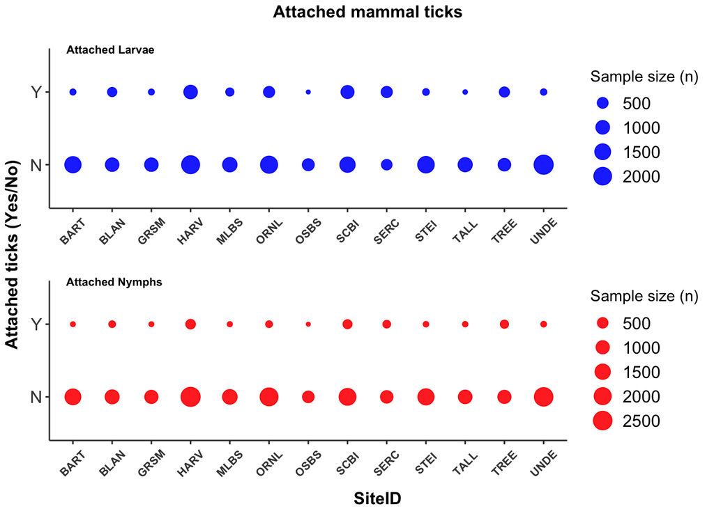

**Type 5.B**

- I was trying to combine two plots into one, but the No for nymphs overshadows the larval data
- I can keep fiddling around with this figure to make aesthetics more appealing/easy to interpret

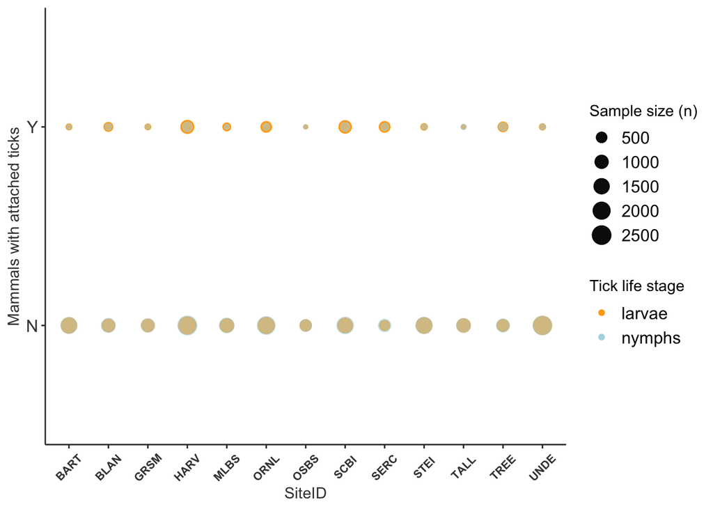

## Graph type 6

*Histogram of attached ticks by life stage*

- Not really helpful I don’t think for the proposal, I think mosaic plot was a helpful way for me to visualize this data but it basically highlights that there’s less attached tick data to use vs. attached tick data which may not help part of the proposal that suggests using larval burden data to make up for the lack of questing larval data in 2016/2017

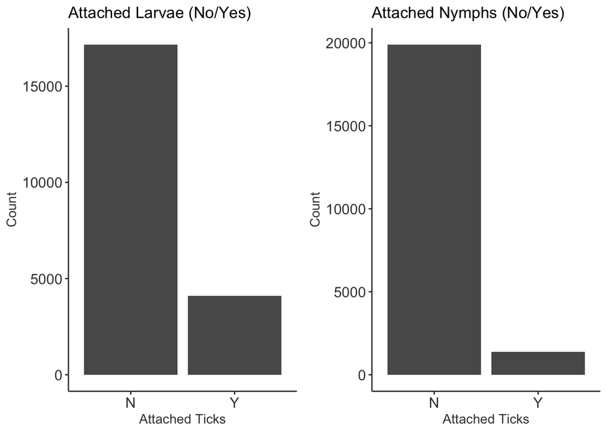